# Analysis of the Major Storm and Weather events in the US from 1950 to 2011.

In this project we aim to analyse the U.S. National Oceanic and Atmospheric Administration (NOAA) database from 1950 to 2011 and adress the following questions: i) Which events are the most harmful to population health? ii) Which events have the gratest economic consequences?. Our results showed that tornados accounted the highest Fatalities and Injuries in the last 61 years in the US ~ 37 % of the Fatalities and 65% of the injuries. Hurricanes and Typhoons, followed by Floods were the most expensive events to the US, accounting for 37, 36.4 and 10.5 % of the total expenses. Crop related expenses were more than 4-fold the Properties expenses.

## Data Processing

```r
setwd("C:/Users/Marcelo/Desktop/Data Science/Data-Science-Specialization/Reproducible Research/")
destfile="./NOAA.csv.bz2"
fileURL <-"https://d396qusza40orc.cloudfront.net/repdata%2Fdata%2FStormData.csv.bz2"
download.file(fileURL ,destfile,method="auto")

NOAA <- read.csv("NOAA.csv.bz2", header = TRUE, stringsAsFactors = FALSE)

head(NOAA)
```

```
##   STATE__           BGN_DATE BGN_TIME TIME_ZONE COUNTY COUNTYNAME STATE
## 1       1  4/18/1950 0:00:00     0130       CST     97     MOBILE    AL
## 2       1  4/18/1950 0:00:00     0145       CST      3    BALDWIN    AL
## 3       1  2/20/1951 0:00:00     1600       CST     57    FAYETTE    AL
## 4       1   6/8/1951 0:00:00     0900       CST     89    MADISON    AL
## 5       1 11/15/1951 0:00:00     1500       CST     43    CULLMAN    AL
## 6       1 11/15/1951 0:00:00     2000       CST     77 LAUDERDALE    AL
##    EVTYPE BGN_RANGE BGN_AZI BGN_LOCATI END_DATE END_TIME COUNTY_END
## 1 TORNADO         0                                               0
## 2 TORNADO         0                                               0
## 3 TORNADO         0                                               0
## 4 TORNADO         0                                               0
## 5 TORNADO         0                                               0
## 6 TORNADO         0                                               0
##   COUNTYENDN END_RANGE END_AZI END_LOCATI LENGTH WIDTH F MAG FATALITIES
```

[output cut: 20 more lines]

There are several variables that will not be used in this project, so I will subset the loaded data set.

The variables we will use are:

EVTYPE as a measure of event type (e.g. tornado, flood, etc.)  
FATALITIES as a measure of harm to human health  
INJURIES as a measure of harm to human health  
PROPDMG as a measure of property damage and hence economic damage in USD  
PROPDMGEXP as a measure of magnitude of property damage (e.g. thousands, millions USD, etc.) CROPDMG as a measure of crop damage and hence economic damage in USD  
CROPDMGEXP as a measure of magnitude of crop damage (e.g. thousands, millions USD, etc.)

```r
vars <- c("EVTYPE", "FATALITIES", "INJURIES", "PROPDMG", "PROPDMGEXP", "CROPDMG", "CROPDMGEXP")

NOAA_dat <- NOAA[vars]

# Check for missing values NA's
sum(is.na(NOAA_dat)) # no NA's
```

```
## [1] 0
```

Economic values are stored in separated columns described with letters:  
H = Hundreds, K = Thousands, M = Millions, B = Billions. Calculations of the total value could be trick:

```r
exp <- function(e){
  if(e %in% c("h","H"))
    return(2)
  else if(e %in% c("k","K"))
    return(3)
  else if(e %in% c("m","M"))
    return(6)
  else if(e %in% c("b","B"))
    return(9)
  else if(!is.na(as.numeric(e)))
    return(as.numeric(e))
  else if (e %in% c("", "-", "?", "+"))
    return(0)
  else{
    stop("invalid Value.")
  }
}
```

Assinging values to Property damages and crop damages

```r
propExp <- sapply(NOAA_dat$PROPDMGEXP, FUN = exp)
NOAA_dat$PropDamage <- NOAA_dat$PROPDMG*(10**propExp)
cropExp <-  sapply(NOAA_dat$CROPDMGEXP, FUN = exp)
NOAA_dat$CropDamage <- NOAA_dat$CROPDMG*(10**propExp)
```

Removing unused columns

```r
NOAA_dat$PROPDMG <- NULL
NOAA_dat$PROPDMGEXP <- NULL
NOAA_dat$CROPDMG <- NULL
NOAA_dat$CROPDMGEXP <- NULL
```

## Results

### Fatalities and Injuries

```r
library(dplyr)
```

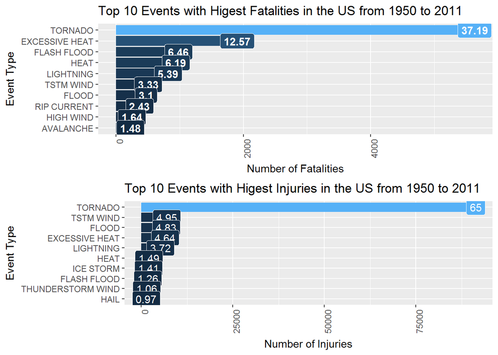

```r
library(ggplot2)
library(gridExtra)
fatality_events <- NOAA_dat %>%
  group_by(EVTYPE) %>%
  summarise(Fatalities = sum(FATALITIES),
            Percentage = round(Fatalities/sum(NOAA_dat$FATALITIES)*100,2))%>%
  arrange(desc(Fatalities)) %>%
  head(10)

injury_events <- NOAA_dat %>%
  group_by(EVTYPE) %>%
  summarise(Injuries = sum(INJURIES),
            Percentage = round(Injuries/sum(NOAA_dat$INJURIES)*100,2))%>%
  arrange(desc(Injuries)) %>%
  head(10)

p1 <- ggplot(data = fatality_events, aes(x = reorder(EVTYPE, Fatalities), y = Fatalities,
                           fill = Fatalities, label = round(Percentage,2)))+
  geom_bar(stat = "identity")+
  coord_flip()+
  theme(axis.text.x = element_text(angle = 90, hjust = 1))+
  xlab("Event Type")+
  ylab("Number of Fatalities")+
  ggtitle("Top 10 Events with Higest Fatalities in the US from 1950 to 2011")+
  theme(legend.position="none")+
  geom_label(aes(fill = Fatalities), colour = "white", fontface = "bold")


p2 <- ggplot(data = injury_events, aes(x = reorder(EVTYPE, Injuries), y = Injuries,
                                         fill = Injuries, label = round(Percentage,2)))+
  geom_bar(stat = "identity")+
  coord_flip()+
  theme(axis.text.x = element_text(angle = 90, hjust = 1))+
  xlab("Event Type")+
  ylab("Number of Injuries")+
  ggtitle("Top 10 Events with Higest Injuries in the US from 1950 to 2011")+
  theme(legend.position="none")+
  geom_label(aes(fill = Injuries), colour = "white")

grid.arrange(p1, p2, nrow = 2)
```

Tornados were responsible for the highest Fatalities and Injuries in the last 61 years in the US reponsible for ~ 37 % of the Fatalities and 65% of the injuries.

In the fatalitites case, Excessive heat, flash food, heat and lightning complete the top 5 events accounting for more than 67 % of the fatalities during the period.

### Economic Impact

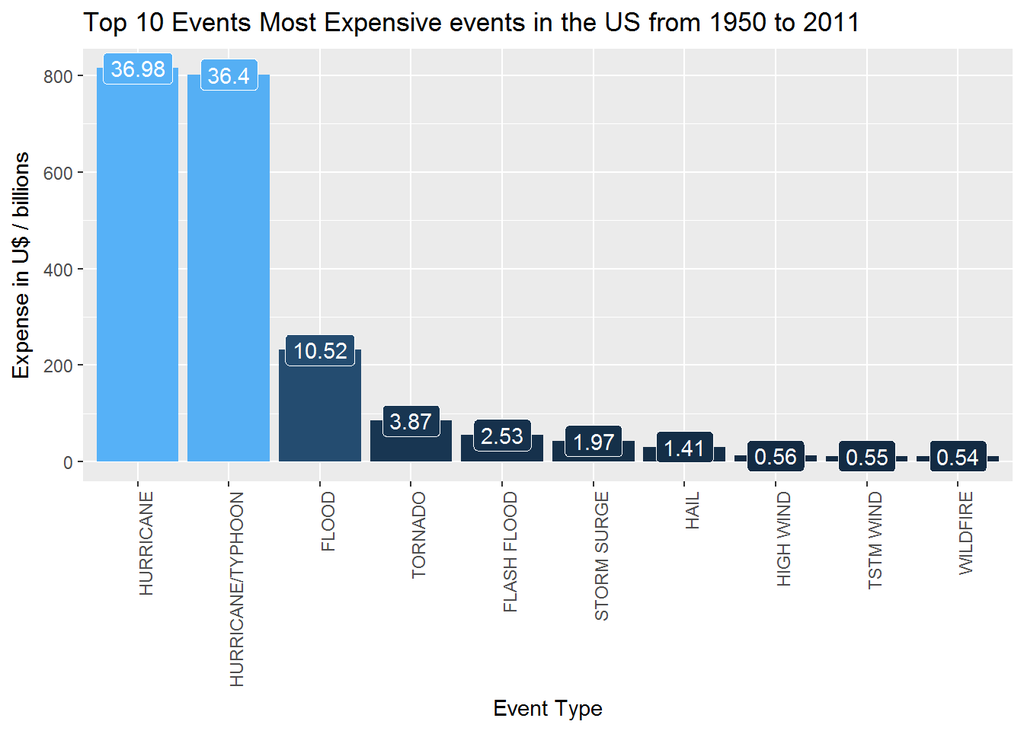

```r
NOAA_dat$TotalDMG <- NOAA_dat$PropDamage + NOAA_dat$CropDamage

TotalDMG <- NOAA_dat %>%
  group_by(EVTYPE) %>%
  summarise(Total = sum(TotalDMG),
            Percentage = round(Total/sum(NOAA_dat$TotalDMG)*100,2))%>%
  arrange(desc(Total)) %>%
  head(10)

ggplot(data = TotalDMG, aes(x = reorder(EVTYPE, -Total), y = Total/1000000000,
                                       fill = Total, label = round(Percentage,2)))+
  geom_bar(stat = "identity")+
  theme(axis.text.x = element_text(angle = 90, hjust = 1))+
  xlab("Event Type")+
  ylab("Expense in U$ / billions")+
  ggtitle("Top 10 Events Most Expensive events in the US from 1950 to 2011")+
  theme(legend.position="none")+
  geom_label(aes(fill = Total), colour = "white")
```

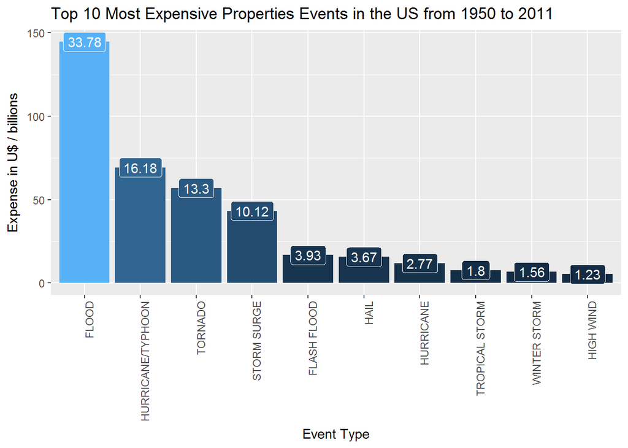

```r
proDMG <- NOAA_dat %>%
  group_by(EVTYPE) %>%
  summarise(Total = sum(PropDamage),
            Percentage = round(Total/sum(NOAA_dat$PropDamage)*100,2))%>%
  arrange(desc(Total)) %>%
  head(10)

ggplot(data = proDMG, aes(x = reorder(EVTYPE, -Total), y = Total/1000000000,
                                  fill = Total, label = round(Percentage,2)))+
  geom_bar(stat = "identity")+
  theme(axis.text.x = element_text(angle = 90, hjust = 1))+
  xlab("Event Type")+
  ylab("Expense in U$ / billions")+
  ggtitle("Top 10 Most Expensive Properties Events in the US from 1950 to 2011")+
  theme(legend.position="none")+
  geom_label(aes(fill = Total), colour = "white")
```

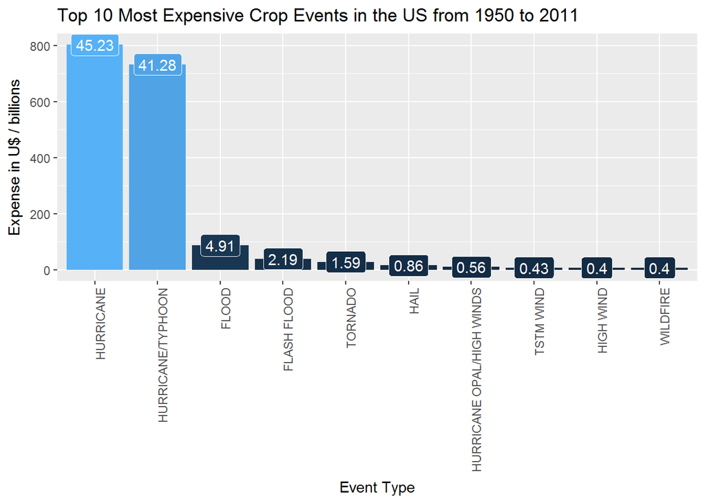

```r
cropDMG <- NOAA_dat %>%
  group_by(EVTYPE) %>%
  summarise(Total = sum(CropDamage),
            Percentage = round(Total/sum(NOAA_dat$CropDamage)*100,2))%>%
  arrange(desc(Total)) %>%
  head(10)

ggplot(data = cropDMG, aes(x = reorder(EVTYPE, -Total), y = Total/1000000000,
                                fill = Total, label = round(Percentage,2)))+
  geom_bar(stat = "identity")+
  theme(axis.text.x = element_text(angle = 90, hjust = 1))+
  xlab("Event Type")+
  ylab("Expense in U$ / billions")+
  ggtitle("Top 10 Most Expensive Crop Events in the US from 1950 to 2011")+
  theme(legend.position="none")+
  geom_label(aes(fill = Total), colour = "white")
```

Considering the economic impact during the 61 years period, Hurricanes and Typhoons, followed by Floods were the most expensive events to the US, accounting for 37, 36.4 and 10.5 % of the total expenses so far, respectively.

It worth mentioning that the economic damages related to the Crop were more than 4 times the economic loss related to the Properties.

# Conclusion

Tornados accounted the highest Fatalities and Injuries in the last 61 years in the US ~ 37 % of the Fatalities and 65% of the injuries. Hurricanes and Typhoons, followed by Floods were the most expensive events to the US, accounting for 37, 36.4 and 10.5 % of the total expenses. Crop related expenses were more than 4-fold the Properties expenses.